# BSU Prof Salary vs Prof Rating

*Research Question:*

Is there a linear relationship between a professor’s rating and their base pay (salary)?

*About the Data:*

Sources

Professor Rating Data: Ratings were obtained from Rate My Professors, an online platform where students submit evaluations of their instructors. The site provides numerical ratings that reflect students’ perceptions of teaching quality, clarity, and overall experience. These ratings are aggregated on a scale (typically 1.0–5.0) and used here as the measure of professor rating.

Salary Data: Base pay (salary) information was downloaded from the Massachusetts State Payroll website, which publishes payroll details for state employees. Specifically, the dataset comes from the full-time employee records for the year 2025 at Bridgewater State University (BSC). Only employees with the title “Professor” were retained for this analysis. The payroll data provides precise base pay amounts for each individual listed.

Key Variables

Base Pay: The annual salary of each professor as reported in the Massachusetts State Payroll database. This variable is quantitative and serves as the response variable in the analysis.

Rating: The average professor rating obtained from Rate My Professors. This is a numeric score representing student evaluation and is used as the explanatory variable in the analysis.

Employees / Identifiers: The dataset includes the name of each professor to match salary to rating. No personally sensitive data beyond names and professional information is used.

Department: Each professor’s department (e.g., math, biology, sociology). While included in the dataset for context, department was not directly used in the primary statistical tests of rating vs salary.

Data Structure and Format

The dataset consists of one row per professor. Each row includes the following columns:

Employees: Professor’s name

Base Pay: Annual salary from state payroll

dept: Department of appointment

rating: Professor’s average rating from Rate My Professors

All variables used in the core analysis are quantitative, which allows for the use of scatterplots, correlation analysis, and simple linear regression to examine the relationship between professor ratings and salaries.

Data Integration Notes

Matching rating values with salary records required manual alignment between the two sources. Professors were included only if they appeared in both the payroll dataset and Rate My Professors. Records lacking a rating or salary were excluded from the analysis. Outliers (e.g., unusually low salaries likely due to payroll reporting artifacts) were examined during graphical analysis but retained unless clearly erroneous.

Load the data:

```r
BSU <- read.csv("BSU_prof_salary.csv")
BSU
```

| Employees | Base.Pay | dept | rating |
| --- | --- | --- | --- |
| Kathleen Ferris | 109385.83 | marketing | 2.6 |
| Uma Shama | 106233.94 | math | 4.3 |
| Steven Greenberg | 120793.52 | education | 4.3 |
| Patricia Bancroft | 109446.72 | accounting | 3.4 |
| Xiangrong Liu | 111842.88 | management | 3.6 |
| Diana Fox | 97279.12 | anthropology | 2.8 |
| Walter Carroll | 108833.04 | social science | 2.9 |
| Martin Grossman | 108555.61 | business | 4.4 |
| Chien Yu | 106674.74 | physical education | 1.7 |
| Jo Hoffman | 102163.20 | education | 3.3 |

[output cut: 165 more lines]

```r
NA
```

[output not shown]

### Initial Scatterplot

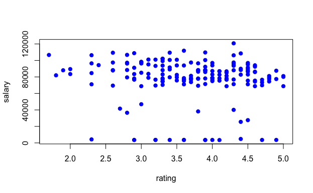

```r
plot(rating, salary, pch=19, col="blue")
```

*Interpretation*

*response*: Salary

*explanatory*: Rating

*direction*: No clear pattern

*form*: No clear pattern

*Strength*: Points are widely spread out, with the trend barely visible

## Correlation Analysis

### Calculate Correlation Coefficient

```r
r <-cor(salary,rating)
r
```

```
[1] -0.07438245
```

```r
r< 0.3
```

```
[1] TRUE
```

```r
r2 <- r^2
r2
```

```
[1] 0.005532748
```

**Interpretation:** - *r* = -0.074: r is close to 0 and is less than 0.3 suggesting a weak or no linear relationship.

- *r²* = 0.0055: This indicates a very weak relationship between the predictor variables and the response variable.
- *Conclusion*: The relationship is weak

## Linear Regression Analysis

### Fit Least-Squares Regression Line

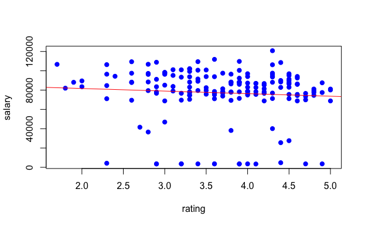

```r
BSU.lm <- lm(salary ~ rating, data = BSU)
plot(salary ~ rating, pch=19, col="blue")
abline(BSU.lm, col="red")
```

### Model Summary

**Sample size:** n = 175 professors **Regression equation:** ŷ = 87,024 - 2,687x - Intercept: $87,024 (predicted salary when rating = 0) - Slope: -$2,687 (for each 1-point increase in rating, salary decreases by $2,687)

### Residual Plot

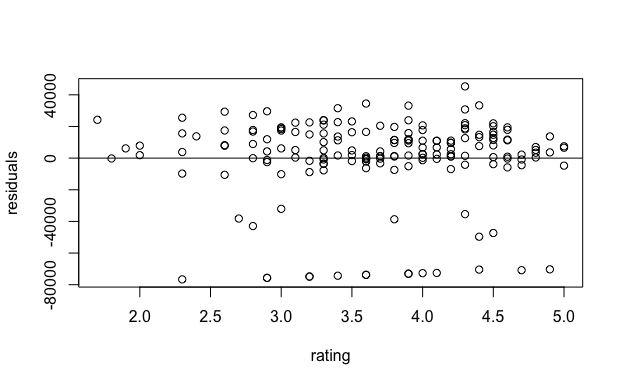

```r
residuals <- resid(BSU.lm)


plot(rating, residuals)
abline(0, 0)
```

**Findings:** - **Pattern observed:** Random scatter around 0

- **Linearity appropriate?** Yes. The residual plot shows random scatter with no systematic curved pattern, fan-shaped spread, or other violations of linearity assumptions. A linear model is appropriate for these data.
- **However:** The extremely weak correlation (r = -0.074, r² = 0.0055) indicates that while a linear model is appropriate, it has very little predictive value. The randomness in the residual plot reflects the fact that rating explains almost none of the variability in salary.
- **Outliers identified:** “Potential outlier(s): Yes, at least one potential outlier detected:
- **Low-end outlier:** One professor has a residual of approximately -$76,623, meaning their actual salary is about $76,623 LOWER than predicted by their rating. This is substantially larger than the typical residual range (middle 50% of residuals fall between -$1,246 and +$15,616).
- **High-end outlier:** One professor has a residual of approximately +$45,324, indicating their salary is about $45,324 HIGHER than predicted. While large, this is less extreme than the low-end outlier.

The presence of these outliers, particularly the -$76,623 residual, suggests there may be individual cases where rating and salary are not aligned in the expected way. This could represent part-time faculty, visiting professors, or other special employment situations.

### Calculate Standard Deviation About the Line (sₑ) and Coefficient of Determination (r²)

```r
summary(BSU.lm)
```

```
Call:
lm(formula = salary ~ rating, data = BSU)

Residuals:
   Min     1Q Median     3Q    Max
-76623  -1246   5167  15616  45324

Coefficients:
            Estimate Std. Error t value Pr(>|t|)
(Intercept)    87024      10318   8.435 1.27e-14 ***
rating         -2687       2739  -0.981    0.328
---
Signif. codes:  0 ‘***’ 0.001 ‘**’ 0.01 ‘*’ 0.05 ‘.’ 0.1 ‘ ’ 1

Residual standard error: 26640 on 173 degrees of freedom
Multiple R-squared:  0.005533,  Adjusted R-squared:  -0.0002156
F-statistic: 0.9625 on 1 and 173 DF,  p-value: 0.3279
```

**Interpretation:**

**sₑ = $26,640**

The typical prediction error for salary is approximately $26,640. This means that when we use a professor’s rating to predict their salary, our predictions are typically off by about $26,640. This represents approximately 35% of the mean salary ($77,097), indicating very poor predictive accuracy.

**r² = 0.0055 (0.55%)**

Only 0.55% of the variability in professor salaries is explained by their rating. This is extremely low, indicating that rating has almost no explanatory power for predicting salary. Over 99% of the variation in salaries must be due to other factors (rank, experience, department, etc.).

### Statistical Significance

**Hypotheses:** - H₀: β = 0 (no linear relationship) - Hₐ: β ≠ 0 (linear relationship exists)

**Results:** - t-statistic: -0.981 - p-value: 0.328 - α = 0.05

**Decision:** Fail to reject H₀ (p-value = 0.328 > 0.05)

**Conclusion:** There is no convincing evidence of a linear relationship between professor rating and salary. The observed negative slope could easily be due to random chance rather than a true relationship.